# NonlinearLeastSquares_Solutions

```r
library(tidyverse)
library(ggplot2)
library(readr)
library(broom)
library(readr)
powerlift <- read_csv("openpl_sample_female.csv")
```

Powerlifting is a strength sport where participants compete to lift the heaviest weight. Competitors compete within weight classes, so their opponents are around the same weight as them. The sport consists of three different lifts: Squat, Bench, and Deadlift. Squat lifts require lifters to squat so that their hips are below their knees and lift the weight to a specific depth. Bench lifts are done while the lifter is lying on a bench. Bench lifters start with the bar weight being held in the air and must lower the bar down to their body. Once the bar touches their body, lifters wait for the command to lift the bar back into the air with their elbows fully extended. Deadlifting, like squats, start with the lifter standing up. The lifter must lift the bar off the ground and get into the position where their shoulders are back and knees are locked. Competitors are overseen by three judges who determine whether the lift follows the rules of the events. If a judge believes the lifter followed the rules, they will turn on a white light. In order for a lift to count, competitors must receive at least two white lights.

The Powerlifting dataset features data from individual lifters during their most recent competitions. Variables include characteristics such as sex, age, birth year and age classes, and division. Other variables include 3 types of weightlifting: squats, benches, and deadlifts.The relevant variables for this specific module are Age and Deadlift.

For the sake of this module, the data set was tidied so that it only included the event “SBD” (Squat, Bench, Deadlift) and two types of equipment use: Raw, meaning no equipment except knee sleeves, and Single-ply, which is a single layer suit. The data was also tided to exclude any lifter that did not finish the competition or had missing information for key variables like Age.

For this worksheet, the data has been updated to only include female competitors to use Age as predictors for Deadlift.

1 - Graph a scatterplot of Deadlift amount versus age. Add a smoother. Comment on the trend you see.

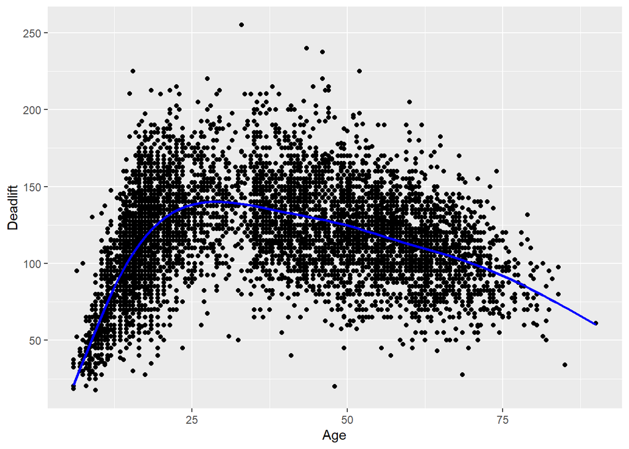

```r
ggplot(data = powerlift, aes(x = Age, y = Deadlift)) +
  geom_point() +
  geom_smooth(color = "blue", se = FALSE)
```

**There is a clear non-linear trend. Specifically, we see a fast increase (“growth”) in deadlift amount initially, leading to a peak in deadlift amount around age 25 or so. After that peak, there is a slow, steady deadline (“decay”) in deadlift amount.**

$$y = axe^{-bx}$$

Use the provided figure to summarize how values of the parameters $a$ and $b$ affect this growth-decay curve.

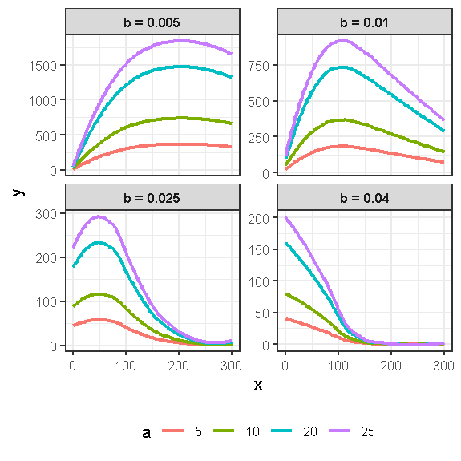

Growth-decay curves

**From the figure, we see that the b parameter seems to control the peak’s location along the x-axis, along with the amount of growth prior to the peak. Specifically, for the smallest b (b=0.005), the peak is further along the x-axis, meaning that there is a longer growth period leading to the peak. For the largest b (b=0.04), the peak is very close to x=0, meaning that there is very little growth before the peak. The a parameter seems to control the height of the curve/peak, with larger a creating a higher peak for a given b.**

3 - When it comes to fitting a non-linear regression model, closed form solutions (e.g., derivable formulas) do not usually exist and numerical optimization methods are needed to obtain estimates of the model parameters. While we will not delve into the specifics of how a numerical optimization algorithm works, most algorithms require the user to specify “initial values” to start the optimization. These initial values can be thought of a guesses about what the model parameters might be. These guesses do not need to be perfect, but if the guesses are “bad,” it might take the algorithm longer to find the optimal parameter estimates.

Use this R chunk to define the form of our growth-decay curve.

```r
# Define growth-decay curve

growth_decay_curve1 <- function(x, a, b) {
  a * x * exp(-b * x)}
```

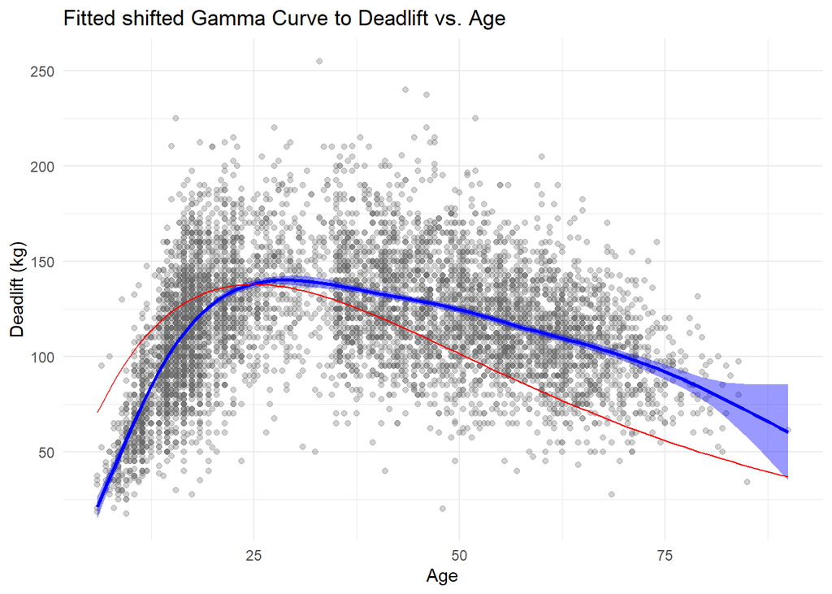

```r
ggplot(powerlift, aes(x = Age)) +
  geom_point(aes(y = Deadlift),
             alpha = 0.3, color = "gray40") +
  geom_smooth(aes(y = Deadlift), color = "blue", fill = "blue") +
  geom_function(fun = function(x) {(15)*(x)*exp((-0.04)*(x))} ,color="red") +
 labs(title = "Fitted shifted Gamma Curve to Deadlift vs. Age",
   x = "Age",
   y = "Deadlift (kg)") +
 theme_minimal()
```